# Расчёт потерь давления (напора) в отводе

Общий коэффициент гидравлического сопротивления отвода $\zeta$ для удобства инженерных расчётов в большинстве случаев определяется как сумма коэффициентов местного сопротивления $\zeta_м$ и сопротивления трения $\zeta_{тр}$ ([1]):

$$\zeta = \zeta_м + \zeta_{тр}$$

[figure not shown]

Методика и инструментарий нахождения коэффициента сопротивления трения приведены в [2]. При вычислении потерь давления от трения необходимо знать длину рассматриваемого участка. Для отвода с углом поворота $\theta$ и радиусом скругления $R$ длина пути прохождения потока внутри отвода составляет:

$$L = \frac{\pi \theta R}{180}$$

Согласно [1] коэффициент местного сопротивления отвода зависит от угла поворота отвода, его относительного радиуса закругления $R/D$, относительной шероховатости стенок отвода и режима течения (числа Рейнольдса):

$$\zeta_м = AB \cdot k_{\Delta}k_{Re},$$

где коэффициенты: $A$ учитывает угол поворота, $B$ - относительный радиус закругления, $k_{\Delta}$ - влияние относительной шероховатости на величину местных потерь, $k_{Re}$ - влияние числа Рейнольдса на величину местных потерь.

Все созданные для реализации данной расчётной методики функции включены в модуль hydrcalc ([скачать](https://medsv.github.io/dzen/0024/hydrcalc.py) версию 2). Пример использования основной расчётной функции elb_calc_dH см.здесь. Описание всех функций модуля hydrcalc касающихся расчёта гидравлического сопротивления отвода приведены здесь.

Рассмотрим влияние перечисленных выше факторов на значение коэффициента местного сопротивления.

```python
import matplotlib as mpl
import matplotlib.pyplot as plt
plt.rcParams['font.size'] = 12
plt.rcParams['axes.grid'] = True
```

## Угол поворота

стр. 278 в [1]

```python
from scipy.interpolate import interp1d #интерполяция
import numpy as np #работа с массивами
```

```python
degs = np.array([0, 20, 30, 45, 60, 75, 90, 110, 130, 150, 180], dtype = float)
As = np.array([0, .31, .45, .6, .78, 0.9, 1., 1.13, 1.2, 1.28, 1.4], dtype = float)
fA = interp1d(degs, As, kind='linear')
degs = np.linspace(0, 180 , 51)
```

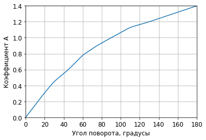

```python
fig, ax = plt.subplots()
ax.plot(degs, fA (degs))
ax.set_xlim(0, 180); ax.set_ylim(0, As[-1])
ax.set_xlabel('Угол поворота, градусы'); ax.set_ylabel('Коэффициент A');
```

## Относительный радиус закругления $R/D$

стр. 279 в [1]

```python
RDs = np.array([.5, .6, .7, .8, .9, 1, 1.25, 1.5, 2, 4, 6, 8, 10, 20, 30, 40])
Bs = np.array([1.18, .77, .51, .37, .28, .21, .19, .17, .15, .11, .09, .07, .07, .05, .04, .03])
fB = interp1d(RDs, Bs, kind='linear')
RD1s = np.linspace(0.5, 2. , 21)
RD2s = np.linspace(2., 40 , 51)
```

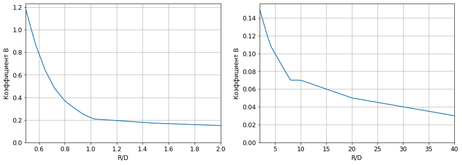

```python
fig, axes = plt.subplots(1,2, figsize = (15, 5))
axes[0].plot(RD1s, fB (RD1s))
axes[0].set_xlim(0.5, 2.); axes[0].set_ylim(0,)
axes[1].plot(RD2s, fB (RD2s))
axes[1].set_xlim(2, 40); axes[1].set_ylim(0,)
for ax in axes:
    ax.set_xlabel('R/D'); ax.set_ylabel('Коэффициент B');
```

## Число Рейнольдса

стр. 279 в [1]

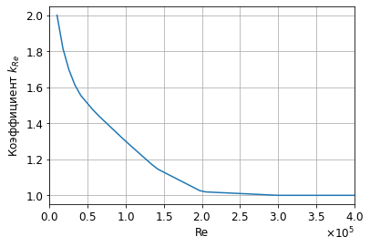

```python
#Для R/DN > 0.7
Res = np.array([.1, .14, .2, .3, .4, .6, .8, 1., 1.4, 2., 3., 4.]) * 1e5
k_Res = np.array([2, 1.89, 1.77, 1.64, 1.56, 1.46, 1.38, 1.3, 1.15, 1.02, 1., 1.])
fk_Re = interp1d(Res, k_Res, kind='linear')
Resi = np.linspace(Res[0], Res[-1], 51)
fig, ax = plt.subplots()
ax.plot(Resi, fk_Re(Resi))
formatter = mpl.ticker.ScalarFormatter(useMathText=True)
formatter.set_scientific(True)
formatter.set_powerlimits((-1,1))
ax.xaxis.set_major_formatter(formatter)
ax.set_xlim(0, Res[-1])
ax.set_xlabel('Re'); ax.set_ylabel('Коэффициент $k_{Re}$');
```

Из графика видно, что коэффициент $k_{Re}$ оказывает влияние на значение коэффициента местного сопротивления только при $Re<2\cdot 10^5$.

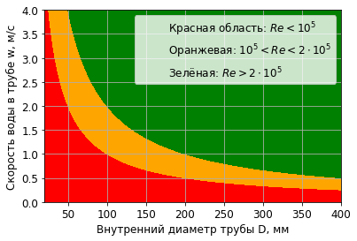

```python
kvisc = 1e-6 #кинематичекая вязкость воды при  t = 20 C
Ds = np.linspace(20, 400, 101) * 1e-3
ws = np.linspace(0, 4, 51)
X, Y = np.meshgrid(Ds, ws)
Z = X * Y / kvisc
fig, ax = plt.subplots()
ax.set_xlabel('Внутренний диаметр трубы D, мм'); ax.set_ylabel('Скорость воды в трубе w, м/с')
ax.contourf(X*1e3, Y, Z, levels = [0, 1e5, 2e5, 2e10], colors=['red','orange', 'green'])
ax.legend(['Красная область: $Re<10^5$','Оранжевая: $10^5<Re<2\cdot 10^5$',
          'Зелёная: $Re>2\\cdot 10^5$']);
```

Из приведённой выше диаграммы видно, что для труб маленького диаметра и (или) при низких скоростях рабочей среды игнорирование влияния числа Рейнольдса на коэффициент местного сопротивления ведёт к занижению его значения более чем на 30% (красная зона).

## Шероховатость

стр. 278 в [1]

Для гладких труб $k_{\Delta} = 1$,  
Для любой шероховатости и $Re<4\cdot 10^4$ $k_{\Delta} = 1$, для $\bar{\Delta}>0.001$ и $Re > 4\cdot 10^4$ $k_{\Delta} = 2$

Для $0\le\bar{\Delta}\le 0.001$ и $Re > 2\cdot 10^5$ $k_{\Delta} = 1 + \bar{\Delta}\cdot 10^3$, при $4\cdot 10^4\le Re\le 2\cdot 10^5$ $k_{\Delta} = \lambda_{\Delta}/\lambda_{гл}$, где $\lambda_{\Delta}$ - для заданной $\Delta$, $\lambda_{гл}$ - гладкой трубы. Рассмотрим данный случай более подробно.

```python
from hydrcalc import calc_lambda #Расчёт коэффициента сопротивления трения единицы относительной длины
```

```python
#Функция для тестирования
def test_lamb(Re, delta):
    w = 3 #скорость, м/с
    kvisc = 1e-6 #кинематическая вязкость воды при t = 20 C, м2/с
    D = Re * kvisc / w #внутренний диаметр трубы, м
    Delta = delta * D #шероховатость стенок трубы, м
    return calc_lambda(w, D, Delta)
```

```python
deltas = np.array([0, 1e-4, 2e-4, 4e-4, 7e-4, 1e-3])
Res = np.linspace(4e4, 2e5, 51)
ks = np.zeros((deltas.shape[0], Res.shape[0]))
for i, delta in enumerate(deltas):
    for j, Re in enumerate(Res):
        ks[i, j] = test_lamb(Re, delta) / test_lamb(Re, 0)
```

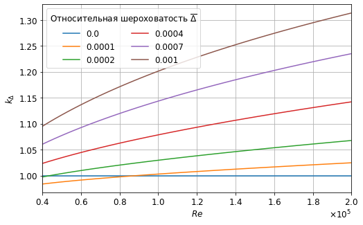

```python
fig, ax = plt.subplots(figsize =(8,5))
for i, delta in enumerate(deltas):
    ax.plot(Res, ks[i][:], label = delta)
ax.set_xlim(Res[0], Res[-1])
ax.set_xlabel('$Re$'); ax.set_ylabel('$k_{\Delta}$')
ax.xaxis.set_major_formatter(formatter)
ax.legend(title = 'Относительная шероховатость $\overline{\Delta}$',ncol = 2);
```

Картина получается нелогичная. Видно, что для $\bar{\Delta} = 0.0001$ при $Re<0.8\cdot 10^5$ $k_{\Delta} < 1$ . Кроме того, при переходе через $Re = 2 \cdot 10^5$ значение $k_{\Delta}$ "прыгает" до значения $1 + \bar\Delta \cdot 10^3$. В связи с этим для относительных шероховатостей в диапазоне $0\le\bar{\Delta}\le 0.001$ при $Re > 4\cdot 10^4$ будем применять формулу $k_{\Delta} = 1 + \bar{\Delta}\cdot 10^3$.

## Пример использования функции `elb_calc_dH`

```python
from hydrcalc import elb_calc_dH
```

```python
help(elb_calc_dH)
```

```
Help on function elb_calc_dH in module hydrcalc:

elb_calc_dH(Q, D, deg=90, RD=1.5, Delta=0, kvisc=1e-06, quadr=False)
    Расчёт потерь давления в отводе, метры столба жидкости
    Q: объёмный расход, м3/ч
    D: внутренний диаметр отвода, м
    deg: угол поворота, градусы (по умолчанию - 90 градусов)
    RD: относительный радиус закругления R/D (по умолчанию - R/D = 1,5)
    Delta: абсолютная шероховатость, м (по умолчанию - отсутствие шероховатости, гладкая труба)
    kvisc: кинематическая вязкость, м2/с (по умолчанию - вязкость воды при 20 С)
    quadr: False (по умолчанию) - не происходит смены формулы при Re>560/delta,
    True - при Re>560/delta применяется формула для квадратичного закона сопротивления
```

```python
D_внешн = 89 #внешний диаметр трубы, мм
h = 3.5 #толщина стенки трубы, мм
deg = 45. #угол поворота
RD = 2 #относительный радиус закругления
D = D_внешн - 2 * h #внутренний диаметр, мм
D *= 1e-3 #перевод в метры
Q = 50 #объёмный расход, м3/ч
Delta=0.3e-3 #шероховатость стенок трубы, м
kvisc = 1.006e-6 #кинематическая вязкость воды при t=20 C
```

```python
dH = elb_calc_dH(Q, D, deg, RD, Delta, kvisc, True)
dH
```

```
0.07990224133833408
```

```python
#По умолчанию deg=90, RD=1.5, Delta=0, kvisc=1e-06, quadr=False
dH = elb_calc_dH(Q, D)
dH
```

```
0.07407393709689833
```

## Примеры реализации расчётной методики

```python
#Загрузим функции для расчёта гидравлического коэффициента сопротивления
#коэффициента сопротивления трения и коэффициента местного сопротивления
from hydrcalc import elb_calc_grc_w, elb_calc_frc_w, elb_calc_lrc_w
```

```python
degs = np.array([30, 45, 60, 90])
w = 2 #скорость рабочей среды
RD = 1.5
Delta = 0.3e-3
kvisc = 1e-6 #кинематическая вязкость (вода при 20 С), м/с2
Ds = np.linspace(40, 1400, 501) / 1e3 #внутренние диаметры отводов, мм
grcs = np.zeros((degs.shape[0], Ds.shape[0])) #значения коэффициента гидравлического сопротивления
lrcs = np.zeros_like(grcs)
frcs = np.zeros_like(grcs)
for i, deg in enumerate(degs):
    for j, D in enumerate(Ds):
        lrcs[i,j] = elb_calc_lrc_w(w, D, deg, RD, Delta, kvisc)
        frcs[i,j] = elb_calc_frc_w(w, D, deg, RD, Delta, kvisc)
        grcs[i,j] = lrcs[i,j] + frcs[i,j]
```

[figure not shown]

```python
fig, axes = plt.subplots(2, 2, figsize = (20,10))
fig.suptitle("Коэффициенты сопротивления отвода (скорость w = 2 м/с, шероховатость $\Delta = 0.3$ мм)")
for i, deg in enumerate(degs):
    axes[0][0].plot(Ds * 1e3, lrcs[i][:], label = deg)
    axes[1][0].plot(Ds * 1e3, frcs[i][:], label = deg)
    axes[1][1].plot(Ds * 1e3, grcs[i][:], label = deg)
axes[0][1].plot(Ds* 1e3, grcs[2][:], label = degs[2], color = 'green')
axes[0][0].set_xlim(0, 1400); axes[0][0].set_ylim(0.08, );
axes[0][1].set_xlim(40, 350); axes[0][1].set_ylim(0.26, 0.42)
axes[1][0].set_xlim(0, 1400); axes[1][0].set_ylim(0.01,)
axes[1][1].set_xlim(0, 1400); axes[1][1].set_ylim(0.1, )
axes[0][0].legend(ncol = 2, title="Угол поворота, градусы")
axes[1][0].legend(ncol = 2, title="Угол поворота, градусы")
axes[1][1].legend(ncol = 2, title="Угол поворота, градусы")
axes[0][0].set_xlabel("$D$, мм"); axes[0][0].set_ylabel("$\zeta_м$")
axes[0][1].set_xlabel("$D$, мм"); axes[0][1].set_ylabel("$\zeta_м$")
axes[1][0].set_xlabel("$D$, мм"); axes[1][0].set_ylabel("$\zeta_{тр}$")
axes[1][1].set_xlabel("$D$, мм"); axes[1][1].set_ylabel("$\zeta = \zeta_м + \zeta_{тр}$")
axes[0][0].set_title("Коэффициент местного сопротивления")
axes[0][1].set_title("Коэффициент местного сопротивления отвода $60^\circ$")
axes[1][0].set_title("Коэффициент сопротивления трения")
axes[1][1].set_title("Коэффициент гидравлического сопротивления");
```

```python
Deltas = np.array([0, 0.1, 0.2, 0.3]) * 1e-3 #шероховатость стенок
deg = 90 #угол поворота
fric_rates = np.zeros((Deltas.shape[0], Ds.shape[0]))
for i, Delta in enumerate(Deltas):
    for j, D in enumerate(Ds):
        fric_rates[i,j] = elb_calc_frc_w(w, D, deg, RD, Delta, kvisc) / \
        elb_calc_grc_w(w, D, deg, RD, Delta, kvisc) * 100
```

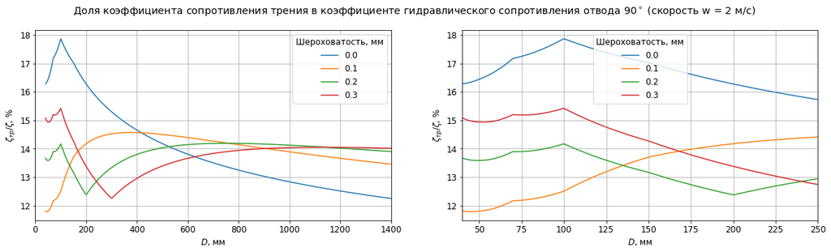

```python
fig, axes = plt.subplots(1, 2, figsize = (20,5))
fig.suptitle("Доля коэффициента сопротивления трения в коэффициенте гидравлического " +
             "сопротивления отвода $90^\circ$ (скорость w = 2 м/с)")
for i, Delta in enumerate(Deltas):
    axes[0].plot(Ds * 1e3, fric_rates[i][:], label = Delta * 1e3)
    axes[1].plot(Ds * 1e3, fric_rates[i][:], label = Delta * 1e3)
axes[0].legend(title="Шероховатость, мм"); axes[1].legend(title="Шероховатость, мм")
axes[0].set_xlim(0, 1400); axes[1].set_xlim(40, 250)
axes[0].set_xlabel("$D$, мм"); axes[0].set_ylabel("$\zeta_{тр}/\zeta$, %")
axes[1].set_xlabel("$D$, мм"); axes[1].set_ylabel("$\zeta_{тр}/\zeta$, %");
```

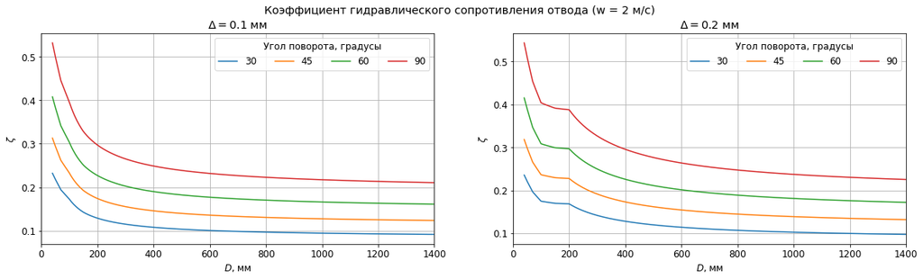

```python
Deltas = np.array([0.1, 0.2]) *1e-3 #шероховатость стенок
grcs = np.zeros((Deltas.shape[0], degs.shape[0], Ds.shape[0]))
fig, axes = plt.subplots(1, 2, figsize = (20,5))
fig.suptitle("Коэффициент гидравлического сопротивления отвода (w = 2 м/с)")
for i, Delta in enumerate(Deltas):
    axes[i].set_title(f"$\Delta = {Delta*1e3}$ мм")
    axes[i].set_xlabel("$D$, мм"); axes[i].set_xlim(0, 1400)
    axes[i].set_ylabel("$\zeta$");
    for j, deg in enumerate(degs):
        for k, D in enumerate(Ds):
            grcs[i,j,k] = elb_calc_grc_w(w, D, deg, RD, Delta, kvisc)
        axes[i].plot(Ds * 1e3, grcs[i][j][:], label = deg)
    axes[i].legend(ncol = 4, title="Угол поворота, градусы");
```

## Описание функций модуля `hydrcalc` для расчёта потерь давления в отводе

```python
from hydrcalc import elb_calc_dH, elb_calc_grc, elb_calc_grc_w, elb_calc_frc, \
elb_calc_frc_w, elb_calc_lrc, elb_calc_lrc_w
```

```python
help(elb_calc_dH)
```

```
Help on function elb_calc_dH in module hydrcalc:

elb_calc_dH(Q, D, deg=90, RD=1.5, Delta=0, kvisc=1e-06, quadr=False)
    Расчёт потерь давления в отводе, метры столба жидкости
    Q: объёмный расход, м3/ч
    D: внутренний диаметр отвода, м
    deg: угол поворота, градусы (по умолчанию - 90 градусов)
    RD: относительный радиус закругления R/D (по умолчанию - R/D = 1,5)
    Delta: абсолютная шероховатость, м (по умолчанию - отсутствие шероховатости, гладкая труба)
    kvisc: кинематическая вязкость, м2/с (по умолчанию - вязкость воды при 20 С)
    quadr: False (по умолчанию) - не происходит смены формулы при Re>560/delta,
    True - при Re>560/delta применяется формула для квадратичного закона сопротивления
```

```python
help(elb_calc_grc)
```

```
Help on function elb_calc_grc in module hydrcalc:

elb_calc_grc(Q, D, deg=90, RD=1.5, Delta=0, kvisc=1e-06, quadr=False)
    Расчёт гидравлического коэффициента сопротивления отвода (местные потери + потери трения)
    Q: объёмный расход, м3/ч
    D: внутренний диаметр отвода, м
    deg: угол поворота, градусы (по умолчанию - 90 градусов)
    RD: относительный радиус закругления R/D (по умолчанию - R/D = 1,5)
    Delta: абсолютная шероховатость, м (по умолчанию - отсутствие шероховатости, гладкая труба)
    kvisc: кинематическая вязкость, м2/с (по умолчанию - вязкость воды при 20 С)
    quadr: False (по умолчанию) - не происходит смены формулы при Re>560/delta,
    True - при Re>560/delta применяется формула для квадратичного закона сопротивления
```

```python
help(elb_calc_grc_w)
```

```
Help on function elb_calc_grc_w in module hydrcalc:

elb_calc_grc_w(w, D, deg=90, RD=1.5, Delta=0, kvisc=1e-06, quadr=False)
    Расчёт гидравлического коэффициента сопротивления отвода (местные потери + потери трения)
    w: скорость потока, м/с
    D: внутренний диаметр отвода, м
    deg: угол поворота, градусы (по умолчанию - 90 градусов)
    RD: относительный радиус закругления R/D (по умолчанию - R/D = 1,5)
    Delta: абсолютная шероховатость, м (по умолчанию - отсутствие шероховатости, гладкая труба)
    kvisc: кинематическая вязкость, м2/с (по умолчанию - вязкость воды при 20 С)
    quadr: False (по умолчанию) - не происходит смены формулы при Re>560/delta,
    True - при Re>560/delta применяется формула для квадратичного закона сопротивления
```

```python
help(elb_calc_frc)
```

```
Help on function elb_calc_frc in module hydrcalc:

elb_calc_frc(Q, D, deg=90, RD=1.5, Delta=0, kvisc=1e-06, quadr=False)
    Расчёт коэффициента сопротивления трения отвода
    Q: объёмный расход, м3/ч
    D: внутренний диаметр отвода, м
    deg: угол поворота, градусы (по умолчанию - 90 градусов)
    RD: относительный радиус закругления R/D (по умолчанию - R/D = 1,5)
    Delta: абсолютная шероховатость, м (по умолчанию - отсутствие шероховатости, гладкая труба)
    kvisc: кинематическая вязкость, м2/с (по умолчанию - вязкость воды при 20 С)
    quadr: False (по умолчанию) - не происходит смены формулы при Re>560/delta,
    True - при Re>560/delta применяется формула для квадратичного закона сопротивления
```

```python
help(elb_calc_frc_w)
```

```
Help on function elb_calc_frc_w in module hydrcalc:

elb_calc_frc_w(w, D, deg=90, RD=1.5, Delta=0, kvisc=1e-06, quadr=False)
    Расчёт коэффициента сопротивления трения отвода
    w: скорость потока, м/с
    D: внутренний диаметр отвода, м
    deg: угол поворота, градусы (по умолчанию - 90 градусов)
    RD: относительный радиус закругления R/D (по умолчанию - R/D = 1,5)
    Delta: абсолютная шероховатость, м (по умолчанию - отсутствие шероховатости, гладкая труба)
    kvisc: кинематическая вязкость, м2/с (по умолчанию - вязкость воды при 20 С)
    quadr: False (по умолчанию) - не происходит смены формулы при Re>560/delta,
    True - при Re>560/delta применяется формула для квадратичного закона сопротивления
```

```python
help(elb_calc_lrc)
```

```
Help on function elb_calc_lrc in module hydrcalc:

elb_calc_lrc(Q, D, deg, RD, Delta, kvisc)
    Расчёт коэффициента местного сопротивления отвода
    Q: объёмный расход, м3/ч
    D: внутренний диаметр отвода, м
    deg: угол поворота, градусы (по умолчанию - 90 градусов)
    RD: относительный радиус закругления R/D (по умолчанию - R/D = 1,5)
    Delta: абсолютная шероховатость, м (по умолчанию - отсутствие шероховатости, гладкая труба)
    kvisc: кинематическая вязкость, м2/с (по умолчанию - вязкость воды при 20 С)
    quadr: False (по умолчанию) - не происходит смены формулы при Re>560/delta,
    True - при Re>560/delta применяется формула для квадратичного закона сопротивления
```

```python
help(elb_calc_lrc_w)
```

```
Help on function elb_calc_lrc_w in module hydrcalc:

elb_calc_lrc_w(w, D, deg, RD, Delta, kvisc)
    Расчёт коэффициента местного сопротивления отвода
    w: скорость потока, м/с
    D: внутренний диаметр отвода, м
    deg: угол поворота, градусы (по умолчанию - 90 градусов)
    RD: относительный радиус закругления R/D (по умолчанию - R/D = 1,5)
    Delta: абсолютная шероховатость, м (по умолчанию - отсутствие шероховатости, гладкая труба)
    kvisc: кинематическая вязкость, м2/с (по умолчанию - вязкость воды при 20 С)
    quadr: False (по умолчанию) - не происходит смены формулы при Re>560/delta,
    True - при Re>560/delta применяется формула для квадратичного закона сопротивления
```

### Ссылки

1. И.Е. Идельчик. Справочник по гидравлическим сопротивлениям. 3-е издание переработанное и дополненное. Москва. "Машиностроение". 1992 г.
2. [Расчёт потерь давления (напора) в трубе](https://medsv.github.io/dzen/0023/grcpipe.html)

[Инженерные расчёты на Python](https://zen.yandex.ru/id/5f33dcd5554adc5b33aaee83), С.В. Медведев, 2020  
[Использование Python и Jupyter Notebook для инженерных расчётов](https://medsv.github.io/), С.В. Медведев, 2020